# Actividad 1.8 Análisis Factorial I

Rey Iván De La Fuente Chávez

2026-09-01

# El problema del Lago

El objetivo es estudiar si las relaciones entre las variables limnológicas pueden explicarse mediante un número reducido de factores latentes. Para ello se analizarán las correlaciones, la viabilidad del análisis factorial y posteriormente se compararán los métodos de máxima verosimilitud y mínimo residuo.

# 0. Preparación de los datos

```r
library(psych)
library(corrplot)
library(performance)
library(GPArotation)
# Seleccionar archivo
datos <- read.csv("C:\\Users\\reyiv\\Downloads\\datoslago.csv")

# Variables que se utilizarán
M <- datos[, c(
  "Tamano",
  "Temperatura",
  "Proteinas",
  "Oxigeno",
  "LnProteinas",
  "LnTamano"
)]

# Eliminar registros incompletos
M <- na.omit(M)

head(M)
```

```
##   Tamano Temperatura Proteinas Oxigeno LnProteinas LnTamano
## 1    7.5        13.8      65.9     2.8    4.188138 2.014903
## 2    5.8        13.8      20.3     2.8    3.010621 1.757858
## 3    8.0        13.8     136.6     2.8    4.917057 2.079442
## 4    8.0        13.8      70.5     2.8    4.255613 2.079442
## 5   10.0        13.8     117.8     2.8    4.768988 2.302585
## 6   10.4        13.8     119.7     2.8    4.784989 2.341806
```

```r
summary(M)
```

```
##      Tamano        Temperatura      Proteinas         Oxigeno
##  Min.   : 2.000   Min.   :13.80   Min.   :  1.50   Min.   :2.400
##  1st Qu.: 7.625   1st Qu.:13.80   1st Qu.: 30.45   1st Qu.:2.800
##  Median :10.200   Median :14.90   Median : 65.75   Median :2.900
##  Mean   : 9.666   Mean   :14.82   Mean   : 82.59   Mean   :2.883
##  3rd Qu.:12.200   3rd Qu.:16.20   3rd Qu.:112.58   3rd Qu.:2.900
##  Max.   :14.700   Max.   :16.20   Max.   :435.30   Max.   :3.400
##   LnProteinas        LnTamano
##  Min.   :0.4055   Min.   :0.6931
##  1st Qu.:3.4144   1st Qu.:2.0310
##  Median :4.1859   Median :2.3224
##  Mean   :3.8804   Mean   :2.1961
##  3rd Qu.:4.7236   3rd Qu.:2.5014
##  Max.   :6.0760   Max.   :2.6878
```

```r
nrow(M)
```

```
## [1] 90
```

La base utilizada contiene 90 observaciones y seis variables numéricas, las cuales serán utilizadas para estudiar la estructura de correlaciones y posteriormente construir los factores.

# 1. Matriz de correlaciones y valores p

Primero se calcula la matriz de correlaciones de Pearson. También se obtienen los valores p para determinar cuáles relaciones son estadísticamente significativas.

```r
Corr <- corr.test(M, adjust = "none")

# Matriz de correlaciones
round(Corr$r, 3)
```

```
##             Tamano Temperatura Proteinas Oxigeno LnProteinas LnTamano
## Tamano       1.000       0.230     0.631  -0.343       0.844    0.974
## Temperatura  0.230       1.000    -0.217   0.338      -0.079    0.216
## Proteinas    0.631      -0.217     1.000  -0.369       0.780    0.571
## Oxigeno     -0.343       0.338    -0.369   1.000      -0.379   -0.306
## LnProteinas  0.844      -0.079     0.780  -0.379       1.000    0.858
## LnTamano     0.974       0.216     0.571  -0.306       0.858    1.000
```

```r
# Valores p
round(Corr$p, 4)
```

```
##             Tamano Temperatura Proteinas Oxigeno LnProteinas LnTamano
## Tamano      0.0000      0.0292    0.0000  0.0009      0.0000   0.0000
## Temperatura 0.0292      0.0000    0.0397  0.0011      0.4600   0.0411
## Proteinas   0.0000      0.0397    0.0000  0.0004      0.0000   0.0000
## Oxigeno     0.0009      0.0011    0.0004  0.0000      0.0002   0.0034
## LnProteinas 0.0000      0.4600    0.0000  0.0002      0.0000   0.0000
## LnTamano    0.0000      0.0411    0.0000  0.0034      0.0000   0.0000
```

## Correlaciones significativas

```r
Corr$p < 0.05
```

```
##             Tamano Temperatura Proteinas Oxigeno LnProteinas LnTamano
## Tamano        TRUE        TRUE      TRUE    TRUE        TRUE     TRUE
## Temperatura   TRUE        TRUE      TRUE    TRUE       FALSE     TRUE
## Proteinas     TRUE        TRUE      TRUE    TRUE        TRUE     TRUE
## Oxigeno       TRUE        TRUE      TRUE    TRUE        TRUE     TRUE
## LnProteinas   TRUE       FALSE      TRUE    TRUE        TRUE     TRUE
## LnTamano      TRUE        TRUE      TRUE    TRUE        TRUE     TRUE
```

La mayoría de las variables presentan correlaciones significativas. Las relaciones positivas más fuertes aparecen entre Tamano y LnTamano (0.974), LnProteinas y LnTamano (0.858) y Tamano y LnProteinas (0.844).

La única relación no significativa al nivel de 0.05 es Temperatura con LnProteinas ($p=0.46$). En general, existe suficiente relación entre varias variables como para continuar evaluando la aplicación del análisis factorial.

# 2. Gráfica de la matriz de correlaciones

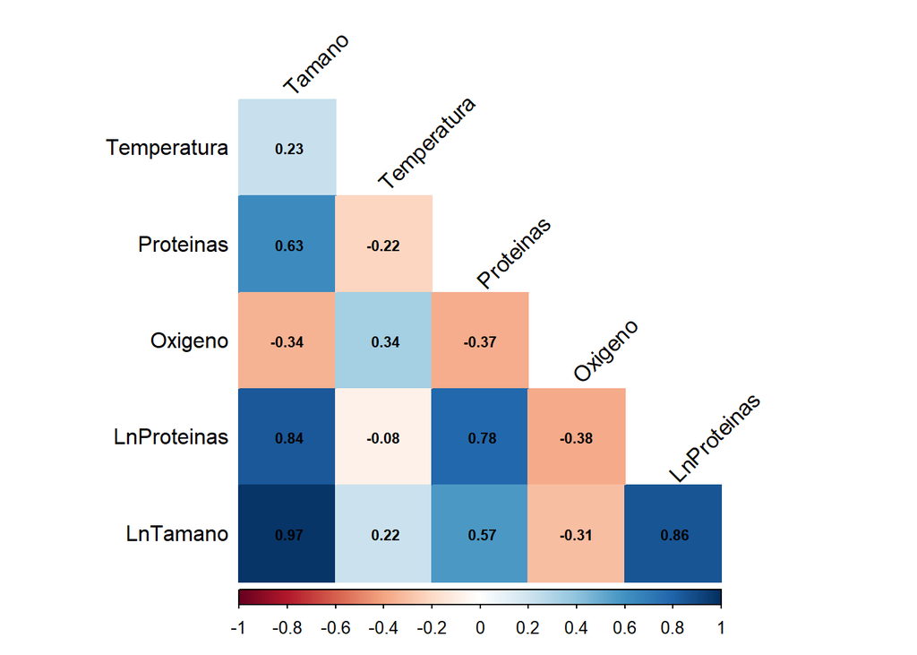

```r
corrplot(
  Corr$r,
  method = "color",
  type = "lower",
  addCoef.col = "black",
  tl.col = "black",
  tl.srt = 45,
  diag = FALSE,
  number.cex = 0.7
)
```

La gráfica confirma que Tamano, LnTamano, Proteinas y LnProteinasforman el grupo con relaciones positivas más fuertes. Oxigeno presenta principalmente relaciones negativas, mientras que Temperatura muestra relaciones más débiles.

# 3. Correlaciones parciales

La correlación parcial mide la relación entre dos variables después de controlar el efecto de las demás.

```r
cor_parcial <- partial.r(Corr$r)

round(cor_parcial, 3)
```

```
##             Tamano Temperatura Proteinas Oxigeno LnProteinas LnTamano
## Tamano       1.000       0.314     0.519  -0.277      -0.236    0.904
## Temperatura  0.314       1.000    -0.212   0.422      -0.247   -0.062
## Proteinas    0.519      -0.212     1.000   0.071       0.625   -0.551
## Oxigeno     -0.277       0.422     0.071   1.000      -0.025    0.169
## LnProteinas -0.236      -0.247     0.625  -0.025       1.000    0.553
## LnTamano     0.904      -0.062    -0.551   0.169       0.553    1.000
```

## Gráfica de correlaciones parciales

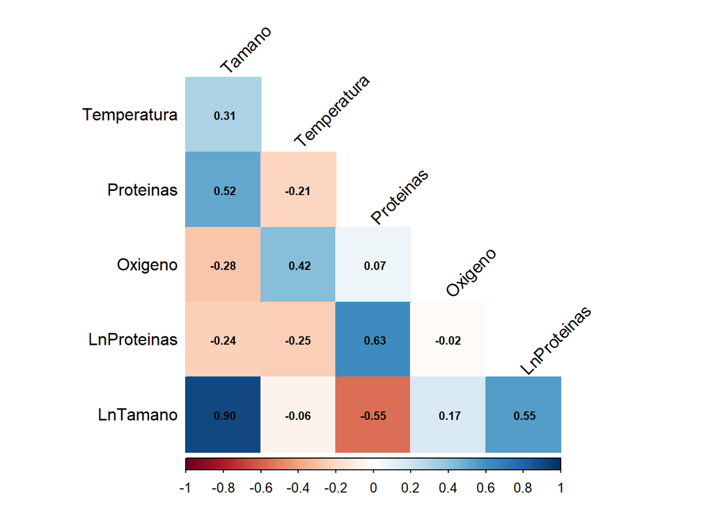

```r
corrplot(
  cor_parcial,
  method = "color",
  type = "lower",
  addCoef.col = "black",
  tl.col = "black",
  tl.srt = 45,
  diag = FALSE,
  number.cex = 0.7
)
```

Al controlar las demás variables, varias correlaciones disminuyen o cambian. Sin embargo, Tamano y LnTamano continúan fuertemente relacionados (0.904) y Proteinas y LnProteinas mantienen una relación importante (0.625).

Esto indica que algunas relaciones originales estaban parcialmente influenciadas por las demás variables.

# 4. Prueba de esfericidad de Bartlett

La prueba de Bartlett permite comprobar si existe correlación conjunta entre las variables.

Las hipótesis son:

$$H_0: R=I$$

La matriz de correlaciones es una matriz identidad y no existe correlación conjunta.

$$H_1: R\neq I$$

Existe correlación conjunta significativa entre las variables.

```r
bartlett <- cortest.bartlett(
  Corr$r,
  n = nrow(M)
)

bartlett
```

```
## $chisq
## [1] 557.8585
##
## $p.value
## [1] 3.135832e-109
##
## $df
## [1] 15
```

```r
bartlett$chisq
```

```
## [1] 557.8585
```

```r
bartlett$df
```

```
## [1] 15
```

```r
bartlett$p.value
```

```
## [1] 3.135832e-109
```

Se obtuvo:

$$\chi^2 = 557.86,\qquad gl=15,\qquad
p<0.001$$

Como el valor p es menor a 0.05, se rechaza $H_0$. Por lo tanto, la matriz de correlaciones es diferente de la identidad y existe correlación conjunta suficiente para considerar el análisis factorial.

# 5. Medida de adecuación muestral KMO

El KMO permite evaluar si las correlaciones tienen una estructura suficientemente compacta para ser explicadas mediante factores comunes.

```r
K <- KMO(Corr$r)

K
```

```
## Kaiser-Meyer-Olkin factor adequacy
## Call: KMO(r = Corr$r)
## Overall MSA =  0.63
## MSA for each item =
##      Tamano Temperatura   Proteinas     Oxigeno LnProteinas    LnTamano
##        0.63        0.41        0.60        0.68        0.73        0.60
```

## KMO global

```r
K$MSA
```

```
## [1] 0.6297281
```

## KMO individual

```r
round(K$MSAi, 3)
```

```
##      Tamano Temperatura   Proteinas     Oxigeno LnProteinas    LnTamano
##       0.629       0.409       0.599       0.677       0.730       0.596
```

El KMO global es 0.63, por lo que la adecuación para realizar análisis factorial es mediocre pero aceptable.

La variable más problemática es Temperatura, con KMO = 0.409. En cambio, LnProteinas presenta el mejor resultado, con 0.730.

Esto no contradice Bartlett: Bartlett indica que sí existen correlaciones entre las variables, mientras que KMO muestra que la estructura factorial de esas correlaciones no es especialmente fuerte.

# 6. Determinación del número de factores

Se utilizarán la gráfica de Cattell y el análisis paralelo.

# 6.1 Gráfica de Cattell

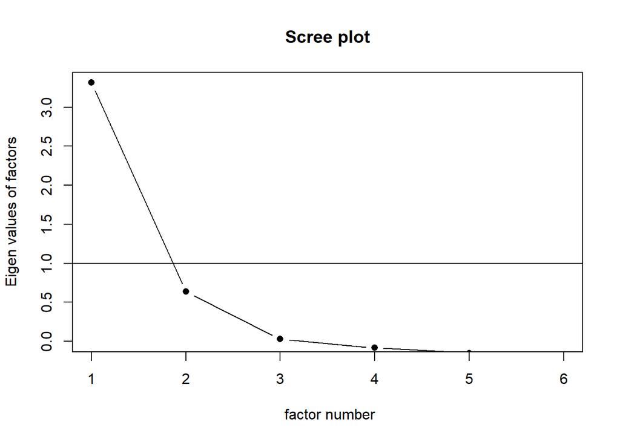

```r
scree(
  M,
  factors = TRUE,
  pc = FALSE
)
```

La gráfica presenta una caída pronunciada en los primeros factores y después comienza a estabilizarse. El cambio de pendiente sugiere conservar aproximadamente **2 factores**.

# 6.2 Análisis paralelo: máxima verosimilitud

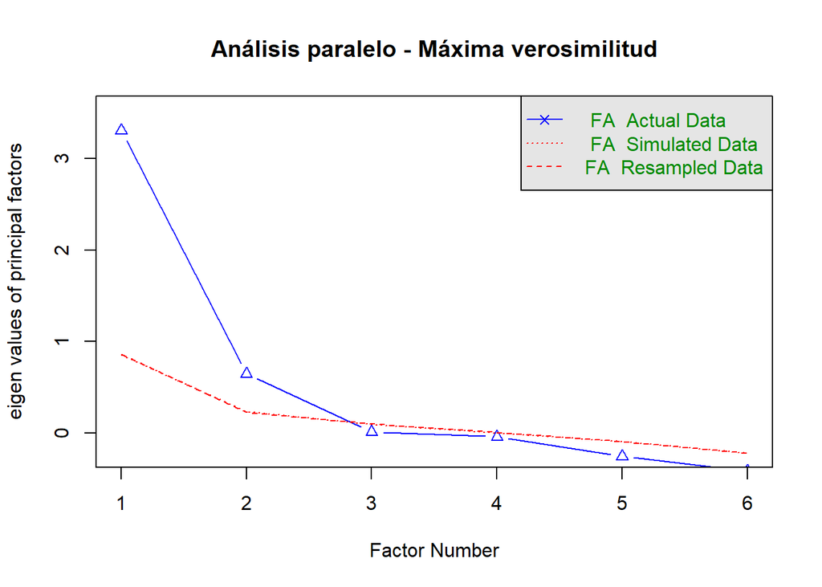

```
## Parallel analysis suggests that the number of factors =  2  and the number of components =  NA
```

```r
set.seed(123)

paralelo_ml <- fa.parallel(
  M,
  fa = "fa",
  fm = "ml",
  n.iter = 100,
  main = "Análisis paralelo - Máxima verosimilitud"
)
```

# 6.3 Análisis paralelo: mínimo residuo

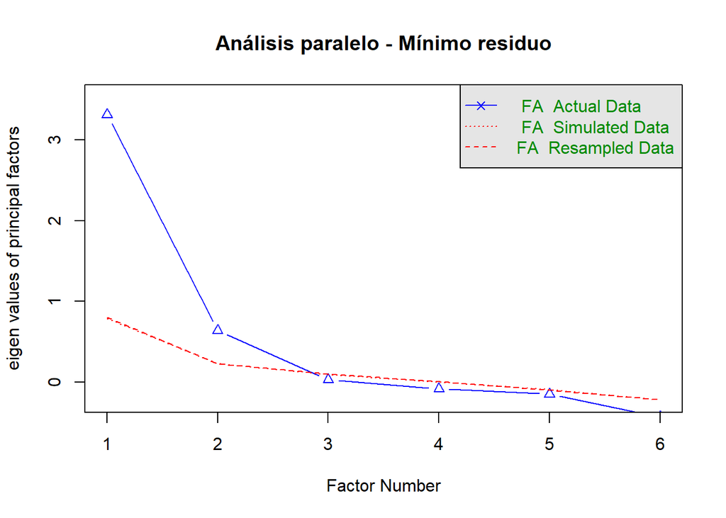

```
## Parallel analysis suggests that the number of factors =  2  and the number of components =  NA
```

```r
set.seed(123)

paralelo_minres <- fa.parallel(
  M,
  fa = "fa",
  fm = "minres",
  n.iter = 100,
  main = "Análisis paralelo - Mínimo residuo"
)
```

Tanto máxima verosimilitud como mínimo residuo recomiendan conservar 2 factores.

Este resultado coincide razonablemente con la gráfica de Cattell, por lo que se utilizarán 2 factores en los modelos posteriores.

# 7. Análisis factorial sin rotación

```r
n_factores <- 2
```

# 7.1 Máxima verosimilitud

```r
modelo_ml <- fa(
  M,
  nfactors = n_factores,
  rotate = "none",
  fm = "ml"
)

print(
  modelo_ml,
  cut = 0.30,
  sort = TRUE
)
```

```
## Factor Analysis using method =  ml
## Call: fa(r = M, nfactors = n_factores, rotate = "none", fm = "ml")
## Standardized loadings (pattern matrix) based upon correlation matrix
##             item   ML1   ML2   h2    u2 com
## LnTamano       6  1.00       1.00 0.005 1.0
## Tamano         1  0.98       0.96 0.044 1.0
## LnProteinas    5  0.87  0.40 0.92 0.082 1.4
## Proteinas      3  0.60  0.64 0.77 0.229 2.0
## Temperatura    2       -0.60 0.40 0.604 1.2
## Oxigeno        4 -0.32 -0.33 0.21 0.793 2.0
##
##                        ML1  ML2
## SS loadings           3.21 1.04
## Proportion Var        0.53 0.17
## Cumulative Var        0.53 0.71
## Proportion Explained  0.76 0.24
## Cumulative Proportion 0.76 1.00
##
## Mean item complexity =  1.4
## Test of the hypothesis that 2 factors are sufficient.
##
## df null model =  15  with the objective function =  6.47 with Chi Square =  557.86
## df of  the model are 4  and the objective function was  0.52
##
## The root mean square of the residuals (RMSR) is  0.06
## The df corrected root mean square of the residuals is  0.11
##
## The harmonic n.obs is  90 with the empirical chi square  4.65  with prob <  0.33
## The total n.obs was  90  with Likelihood Chi Square =  43.94  with prob <  6.6e-09
##
## Tucker Lewis Index of factoring reliability =  0.72
## RMSEA index =  0.333  and the 90 % confidence intervals are  0.25 0.428
## BIC =  25.94
## Fit based upon off diagonal values = 0.99
## Measures of factor score adequacy
##                                                    ML1  ML2
## Correlation of (regression) scores with factors   1.00 0.91
## Multiple R square of scores with factors          1.00 0.82
## Minimum correlation of possible factor scores     0.99 0.65
```

En máxima verosimilitud, el primer factor está asociado principalmente con Tamano, LnTamano, Proteinas y LnProteinas. El segundo factor presenta relaciones importantes con Proteinas y Temperatura.

Los dos factores explican aproximadamente 70.7% de la varianza total.

# 7.2 Mínimo residuo

```r
modelo_minres <- fa(
  M,
  nfactors = n_factores,
  rotate = "none",
  fm = "minres"
)

print(
  modelo_minres,
  cut = 0.30,
  sort = TRUE
)
```

```
## Factor Analysis using method =  minres
## Call: fa(r = M, nfactors = n_factores, rotate = "none", fm = "minres")
## Standardized loadings (pattern matrix) based upon correlation matrix
##             item   MR1   MR2   h2    u2 com
## Tamano         1  0.96       0.97 0.025 1.1
## LnProteinas    5  0.94       0.90 0.097 1.0
## LnTamano       6  0.93       0.92 0.076 1.1
## Proteinas      3  0.73       0.60 0.397 1.3
## Oxigeno        4 -0.40  0.35 0.28 0.716 2.0
## Temperatura    2        0.92 0.85 0.155 1.0
##
##                        MR1  MR2
## SS loadings           3.37 1.16
## Proportion Var        0.56 0.19
## Cumulative Var        0.56 0.76
## Proportion Explained  0.74 0.26
## Cumulative Proportion 0.74 1.00
##
## Mean item complexity =  1.3
## Test of the hypothesis that 2 factors are sufficient.
##
## df null model =  15  with the objective function =  6.47 with Chi Square =  557.86
## df of  the model are 4  and the objective function was  0.92
##
## The root mean square of the residuals (RMSR) is  0.03
## The df corrected root mean square of the residuals is  0.06
##
## The harmonic n.obs is  90 with the empirical chi square  1.14  with prob <  0.89
## The total n.obs was  90  with Likelihood Chi Square =  77.79  with prob <  5.1e-16
##
## Tucker Lewis Index of factoring reliability =  0.482
## RMSEA index =  0.453  and the 90 % confidence intervals are  0.37 0.546
## BIC =  59.79
## Fit based upon off diagonal values = 1
## Measures of factor score adequacy
##                                                    MR1  MR2
## Correlation of (regression) scores with factors   0.99 0.94
## Multiple R square of scores with factors          0.98 0.88
## Minimum correlation of possible factor scores     0.96 0.75
```

Con mínimo residuo, el primer factor también está dominado por Tamano, LnTamano, Proteinas y LnProteinas, mientras que el segundo está principalmente relacionado con Temperatura y, en menor medida, Oxigeno.

Los dos factores explican aproximadamente 75.6% de la varianza, ligeramente más que máxima verosimilitud.

# 8. Comparación de comunalidades

La comunalidad indica qué proporción de la variabilidad de cada variable es explicada por los factores.

```r
tabla_comunalidades <- data.frame(
  Variable = rownames(modelo_ml$loadings),
  Comunalidad_ML = round(modelo_ml$communality, 3),
  Unicidad_ML = round(modelo_ml$uniquenesses, 3),
  Comunalidad_MINRES = round(modelo_minres$communality, 3),
  Unicidad_MINRES = round(modelo_minres$uniquenesses, 3)
)

tabla_comunalidades
```

```
##                Variable Comunalidad_ML Unicidad_ML Comunalidad_MINRES
## Tamano           Tamano          0.956       0.044              0.975
## Temperatura Temperatura          0.396       0.604              0.845
## Proteinas     Proteinas          0.771       0.229              0.603
## Oxigeno         Oxigeno          0.207       0.793              0.284
## LnProteinas LnProteinas          0.918       0.082              0.903
## LnTamano       LnTamano          0.995       0.005              0.924
##             Unicidad_MINRES
## Tamano                0.025
## Temperatura           0.155
## Proteinas             0.397
## Oxigeno               0.716
## LnProteinas           0.097
## LnTamano              0.076
```

Tamano, LnTamano y LnProteinas son bien representadas por los factores en ambos métodos.

La variable peor representada es Oxigeno, con comunalidades de 0.207 en máxima verosimilitud y 0.284 en mínimo residuo.

Mínimo residuo representa especialmente mejor a Temperatura, cuya comunalidad aumenta de 0.396 a 0.845.

# 9. Rotación Varimax

Varimax busca obtener una estructura más clara, haciendo que cada variable tenga cargas altas principalmente en un factor.

# 9.1 Varimax con máxima verosimilitud

```r
modelo_ml_varimax <- fa(
  M,
  nfactors = n_factores,
  rotate = "varimax",
  fm = "ml"
)

print(
  modelo_ml_varimax$loadings,
  cutoff = 0.30,
  sort = TRUE
)
```

```
##
## Loadings:
##             ML1    ML2
## Tamano       0.956
## Proteinas    0.727 -0.493
## LnProteinas  0.939
## LnTamano     0.964
## Temperatura         0.626
## Oxigeno     -0.383
##
##                  ML1   ML2
## SS loadings    3.404 0.839
## Proportion Var 0.567 0.140
## Cumulative Var 0.567 0.707
```

```r
fa.diagram(
  modelo_ml_varimax,
  main = "Varimax - Máxima verosimilitud"
)
```

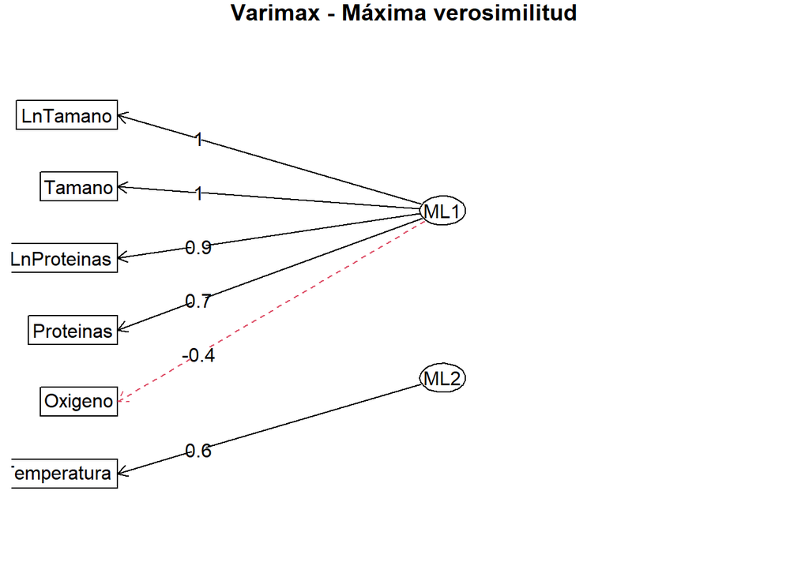

Después de Varimax, el Factor 1 queda principalmente relacionado con Tamano, LnTamano, Proteinas y LnProteinas.

El Factor 2 está relacionado principalmente con Temperatura y también con Proteinas en sentido negativo. La rotación facilita la separación de las variables entre los dos factores.

# 9.2 Varimax con mínimo residuo

```r
modelo_minres_varimax <- fa(
  M,
  nfactors = n_factores,
  rotate = "varimax",
  fm = "minres"
)

print(
  modelo_minres_varimax$loadings,
  cutoff = 0.30,
  sort = TRUE
)
```

```
##
## Loadings:
##             MR1    MR2
## Tamano       0.981
## Proteinas    0.691 -0.354
## LnProteinas  0.922
## LnTamano     0.954
## Temperatura         0.910
## Oxigeno     -0.355  0.397
##
##                  MR1   MR2
## SS loadings    3.343 1.190
## Proportion Var 0.557 0.198
## Cumulative Var 0.557 0.756
```

```r
fa.diagram(
  modelo_minres_varimax,
  main = "Varimax - Mínimo residuo"
)
```

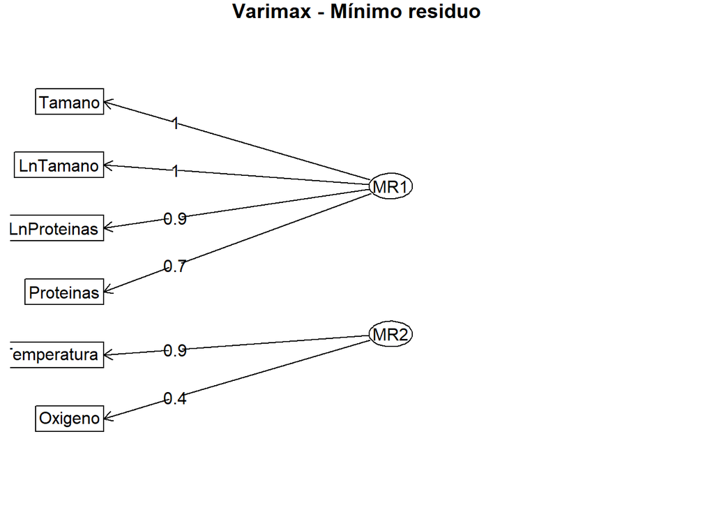

Con mínimo residuo, el Factor 1 vuelve a reunir principalmente Tamano, LnTamano, Proteinas y LnProteinas.

El Factor 2 está claramente dominado por Temperatura (0.910), mientras que Oxigeno presenta una relación positiva moderada (0.397).

Esta solución presenta una separación bastante clara entre los dos factores.

# 10. Rotación Quartimax

Quartimax busca simplificar la representación de cada variable haciendo que dependa de la menor cantidad posible de factores.

# 10.1 Quartimax con máxima verosimilitud

```r
modelo_ml_quartimax <- fa(
  M,
  nfactors = n_factores,
  rotate = "quartimax",
  fm = "ml"
)

print(
  modelo_ml_quartimax$loadings,
  cutoff = 0.30,
  sort = TRUE
)
```

```
##
## Loadings:
##             ML1    ML2
## Tamano       0.969
## Proteinas    0.688 -0.545
## LnProteinas  0.922
## LnTamano     0.981
## Temperatura         0.620
## Oxigeno     -0.364
##
##                  ML1   ML2
## SS loadings    3.368 0.876
## Proportion Var 0.561 0.146
## Cumulative Var 0.561 0.707
```

```r
fa.diagram(
  modelo_ml_quartimax,
  main = "Quartimax - Máxima verosimilitud"
)
```

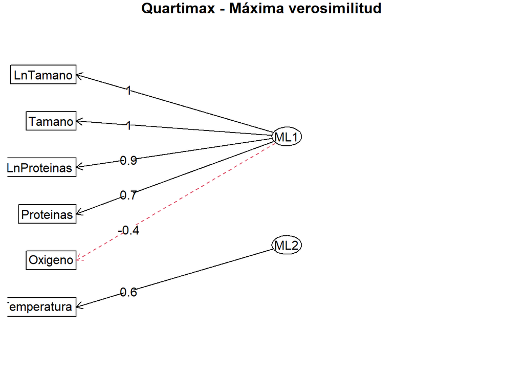

Quartimax produce una estructura muy similar a Varimax. El primer factor concentra principalmente Tamano y las variables relacionadas con proteínas, mientras que el segundo se relaciona principalmente con Temperatura.

# 10.2 Quartimax con mínimo residuo

```r
modelo_minres_quartimax <- fa(
  M,
  nfactors = n_factores,
  rotate = "quartimax",
  fm = "minres"
)

print(
  modelo_minres_quartimax$loadings,
  cutoff = 0.30,
  sort = TRUE
)
```

```
##
## Loadings:
##             MR2    MR1
## Tamano       0.973
## Proteinas    0.710 -0.314
## LnProteinas  0.934
## LnTamano     0.946
## Temperatura         0.916
## Oxigeno     -0.377  0.376
##
##                  MR2   MR1
## SS loadings    3.366 1.167
## Proportion Var 0.561 0.195
## Cumulative Var 0.561 0.756
```

```r
fa.diagram(
  modelo_minres_quartimax,
  main = "Quartimax - Mínimo residuo"
)
```

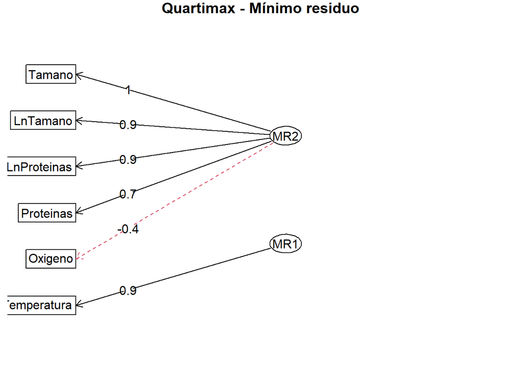

Por lo tanto, las dos rotaciones producen conclusiones similares.

# 11. Comparación de los modelos

## Máxima verosimilitud + Varimax

```r
print(
  modelo_ml_varimax$loadings,
  cutoff = 0.30,
  sort = TRUE
)
```

```
##
## Loadings:
##             ML1    ML2
## Tamano       0.956
## Proteinas    0.727 -0.493
## LnProteinas  0.939
## LnTamano     0.964
## Temperatura         0.626
## Oxigeno     -0.383
##
##                  ML1   ML2
## SS loadings    3.404 0.839
## Proportion Var 0.567 0.140
## Cumulative Var 0.567 0.707
```

## Máxima verosimilitud + Quartimax

```r
print(
  modelo_ml_quartimax$loadings,
  cutoff = 0.30,
  sort = TRUE
)
```

```
##
## Loadings:
##             ML1    ML2
## Tamano       0.969
## Proteinas    0.688 -0.545
## LnProteinas  0.922
## LnTamano     0.981
## Temperatura         0.620
## Oxigeno     -0.364
##
##                  ML1   ML2
## SS loadings    3.368 0.876
## Proportion Var 0.561 0.146
## Cumulative Var 0.561 0.707
```

## Mínimo residuo + Varimax

```r
print(
  modelo_minres_varimax$loadings,
  cutoff = 0.30,
  sort = TRUE
)
```

```
##
## Loadings:
##             MR1    MR2
## Tamano       0.981
## Proteinas    0.691 -0.354
## LnProteinas  0.922
## LnTamano     0.954
## Temperatura         0.910
## Oxigeno     -0.355  0.397
##
##                  MR1   MR2
## SS loadings    3.343 1.190
## Proportion Var 0.557 0.198
## Cumulative Var 0.557 0.756
```

## Mínimo residuo + Quartimax

```r
print(
  modelo_minres_quartimax$loadings,
  cutoff = 0.30,
  sort = TRUE
)
```

```
##
## Loadings:
##             MR2    MR1
## Tamano       0.973
## Proteinas    0.710 -0.314
## LnProteinas  0.934
## LnTamano     0.946
## Temperatura         0.916
## Oxigeno     -0.377  0.376
##
##                  MR2   MR1
## SS loadings    3.366 1.167
## Proportion Var 0.561 0.195
## Cumulative Var 0.561 0.756
```

# 12. Varianza explicada

```r
modelo_ml_varimax$Vaccounted
```

```
##                             ML1       ML2
## SS loadings           3.4041546 0.8391090
## Proportion Var        0.5673591 0.1398515
## Cumulative Var        0.5673591 0.7072106
## Proportion Explained  0.8022491 0.1977509
## Cumulative Proportion 0.8022491 1.0000000
```

```r
modelo_minres_varimax$Vaccounted
```

```
##                             MR1       MR2
## SS loadings           3.3432953 1.1903475
## Proportion Var        0.5572159 0.1983912
## Cumulative Var        0.5572159 0.7556071
## Proportion Explained  0.7374413 0.2625587
## Cumulative Proportion 0.7374413 1.0000000
```

Con máxima verosimilitud, los dos factores explican aproximadamente 70.7% de la varianza.

Con mínimo residuo explican aproximadamente 75.6%, por lo que este método logra representar una mayor proporción de la información de las variables.

# 13. Conclusión

La prueba de Bartlett confirmó que existen correlaciones suficientes para realizar análisis factorial. Sin embargo, el KMO global de 0.63 indica que la adecuación de los datos es solamente moderada y Temperatura presenta un KMO individual bajo.

La gráfica de Cattell y, especialmente, el análisis paralelo apoyan una solución de 2 factores.

El primer factor está relacionado principalmente con Tamano, LnTamano, Proteinas y LnProteinas, mientras que el segundo está relacionado principalmente con Temperatura y Oxigeno. Por lo tanto, aparece una estructura de dos dimensiones, aunque no coincide perfectamente con la separación teórica entre productividad y hábitat.

Entre las soluciones analizadas, mínimo residuo con rotación Varimax resulta la opción más conveniente, ya que presenta una estructura clara, un menor residuo y explica aproximadamente 75.6% de la varianza.

El modelo es razonable para estos datos, pero debe interpretarse con cierta precaución debido al KMO moderado y a la baja comunalidad de Oxigeno.